# chapter3

Ilkka Jokipii

9 helmikuuta 2017

# Logistic regression

## Data descpription

In this chapter I will do logistic regression exercises. Exercises are done with student alcohol consumption data set.

First I combined two smaller data sets and removed duplicates from the combined data set.

After combining the data set I created new combined columns to the data set. I counted average alcohol use from answers on *weekend* and *daily* alcohol consumption (`alc_use`). From that I created a variable `high_use` which is `TRUE` if the average `alc_use` is greater than 2. Data wrangling process in this [file](https://github.com/jokiilk/IODS-project/blob/master/data/create_alc.R)

The combined data set looks like this:

```r
alc <- read.table("data/alc.csv", sep = ",", header = TRUE)
alc$X <- NULL
library(dplyr)
```

```r
head(alc)
```

```
##   school sex age address famsize Pstatus Medu Fedu     Mjob     Fjob
## 1     GP   F  18       U     GT3       A    4    4  at_home  teacher
## 2     GP   F  17       U     GT3       T    1    1  at_home    other
## 3     GP   F  15       U     LE3       T    1    1  at_home    other
## 4     GP   F  15       U     GT3       T    4    2   health services
## 5     GP   F  16       U     GT3       T    3    3    other    other
## 6     GP   M  16       U     LE3       T    4    3 services    other
##       reason nursery internet guardian traveltime studytime failures
## 1     course     yes       no   mother          2         2        0
## 2     course      no      yes   father          1         2        0
## 3      other     yes      yes   mother          1         2        2
## 4       home     yes      yes   mother          1         3        0
## 5       home     yes       no   father          1         2        0
## 6 reputation     yes      yes   mother          1         2        0
##   schoolsup famsup paid activities higher romantic famrel freetime goout
## 1       yes     no   no         no    yes       no      4        3     4
## 2        no    yes   no         no    yes       no      5        3     3
## 3       yes     no  yes         no    yes       no      4        3     2
## 4        no    yes  yes        yes    yes      yes      3        2     2
## 5        no    yes  yes         no    yes       no      4        3     2
## 6        no    yes  yes        yes    yes       no      5        4     2
##   Dalc Walc health absences G1 G2 G3 alc_use high_use
## 1    1    1      3        5  2  8  8     1.0    FALSE
## 2    1    1      3        3  7  8  8     1.0    FALSE
## 3    2    3      3        8 10 10 11     2.5     TRUE
## 4    1    1      5        1 14 14 14     1.0    FALSE
## 5    1    2      5        2  8 12 12     1.5    FALSE
## 6    1    2      5        8 14 14 14     1.5    FALSE
```

```r
str(alc)
```

```
## 'data.frame':    382 obs. of  35 variables:
##  $ school    : Factor w/ 2 levels "GP","MS": 1 1 1 1 1 1 1 1 1 1 ...
##  $ sex       : Factor w/ 2 levels "F","M": 1 1 1 1 1 2 2 1 2 2 ...
##  $ age       : int  18 17 15 15 16 16 16 17 15 15 ...
##  $ address   : Factor w/ 2 levels "R","U": 2 2 2 2 2 2 2 2 2 2 ...
##  $ famsize   : Factor w/ 2 levels "GT3","LE3": 1 1 2 1 1 2 2 1 2 1 ...
##  $ Pstatus   : Factor w/ 2 levels "A","T": 1 2 2 2 2 2 2 1 1 2 ...
##  $ Medu      : int  4 1 1 4 3 4 2 4 3 3 ...
##  $ Fedu      : int  4 1 1 2 3 3 2 4 2 4 ...
##  $ Mjob      : Factor w/ 5 levels "at_home","health",..: 1 1 1 2 3 4 3 3 4 3 ...
##  $ Fjob      : Factor w/ 5 levels "at_home","health",..: 5 3 3 4 3 3 3 5 3 3 ...
##  $ reason    : Factor w/ 4 levels "course","home",..: 1 1 3 2 2 4 2 2 2 2 ...
##  $ nursery   : Factor w/ 2 levels "no","yes": 2 1 2 2 2 2 2 2 2 2 ...
##  $ internet  : Factor w/ 2 levels "no","yes": 1 2 2 2 1 2 2 1 2 2 ...
##  $ guardian  : Factor w/ 3 levels "father","mother",..: 2 1 2 2 1 2 2 2 2 2 ...
```

[output cut: 21 more lines]

```r
summary(alc)
```

```
##  school   sex          age        address famsize   Pstatus
##  GP:342   F:198   Min.   :15.00   R: 81   GT3:278   A: 38
##  MS: 40   M:184   1st Qu.:16.00   U:301   LE3:104   T:344
##                   Median :17.00
##                   Mean   :16.59
##                   3rd Qu.:17.00
##                   Max.   :22.00
##       Medu            Fedu             Mjob           Fjob
##  Min.   :0.000   Min.   :0.000   at_home : 53   at_home : 16
##  1st Qu.:2.000   1st Qu.:2.000   health  : 33   health  : 17
##  Median :3.000   Median :3.000   other   :138   other   :211
##  Mean   :2.806   Mean   :2.565   services: 96   services:107
##  3rd Qu.:4.000   3rd Qu.:4.000   teacher : 62   teacher : 31
##  Max.   :4.000   Max.   :4.000
##         reason    nursery   internet    guardian     traveltime
##  course    :140   no : 72   no : 58   father: 91   Min.   :1.000
##  home      :110   yes:310   yes:324   mother:275   1st Qu.:1.000
##  other     : 34                       other : 16   Median :1.000
##  reputation: 98                                    Mean   :1.448
##                                                    3rd Qu.:2.000
##                                                    Max.   :4.000
##    studytime        failures      schoolsup famsup     paid     activities
##  Min.   :1.000   Min.   :0.0000   no :331   no :144   no :205   no :181
##  1st Qu.:1.000   1st Qu.:0.0000   yes: 51   yes:238   yes:177   yes:201
##  Median :2.000   Median :0.0000
##  Mean   :2.037   Mean   :0.2016
##  3rd Qu.:2.000   3rd Qu.:0.0000
##  Max.   :4.000   Max.   :3.0000
##  higher    romantic      famrel         freetime        goout
##  no : 18   no :261   Min.   :1.000   Min.   :1.00   Min.   :1.000
##  yes:364   yes:121   1st Qu.:4.000   1st Qu.:3.00   1st Qu.:2.000
##                      Median :4.000   Median :3.00   Median :3.000
##                      Mean   :3.937   Mean   :3.22   Mean   :3.113
##                      3rd Qu.:5.000   3rd Qu.:4.00   3rd Qu.:4.000
##                      Max.   :5.000   Max.   :5.00   Max.   :5.000
##       Dalc            Walc           health         absences
##  Min.   :1.000   Min.   :1.000   Min.   :1.000   Min.   : 0.0
##  1st Qu.:1.000   1st Qu.:1.000   1st Qu.:3.000   1st Qu.: 1.0
##  Median :1.000   Median :2.000   Median :4.000   Median : 3.0
##  Mean   :1.482   Mean   :2.296   Mean   :3.573   Mean   : 4.5
##  3rd Qu.:2.000   3rd Qu.:3.000   3rd Qu.:5.000   3rd Qu.: 6.0
##  Max.   :5.000   Max.   :5.000   Max.   :5.000   Max.   :45.0
##        G1              G2              G3           alc_use
##  Min.   : 2.00   Min.   : 4.00   Min.   : 0.00   Min.   :1.000
##  1st Qu.:10.00   1st Qu.:10.00   1st Qu.:10.00   1st Qu.:1.000
##  Median :12.00   Median :12.00   Median :12.00   Median :1.500
##  Mean   :11.49   Mean   :11.47   Mean   :11.46   Mean   :1.889
##  3rd Qu.:14.00   3rd Qu.:14.00   3rd Qu.:14.00   3rd Qu.:2.500
##  Max.   :18.00   Max.   :18.00   Max.   :18.00   Max.   :5.000
##   high_use
##  Mode :logical
##  FALSE:268
##  TRUE :114
##  NA's :0
##
##
```

## Analyzing alcohol consumption

I will look into four variables of the data: `high_use`, `sex` `famrel` and `Pstatus`.

`alc_use` is average of two variables, weekend (`Walc`) and workday (`Dalc`) alcohol use. Both of the original variables are integers ranging from 1 to 5.

`sex` tells us students’ sex. It is a factor variable with 2 levels F (female) and M (male)

`famrel` tells us about quality of students’ family relations. It is a integer variable and values are between 1 (very bad) and 5 (excellent)

`Pstatus` parent’s cohabitation status. Factor with 2 levels: T - living together or A - apart

My personal hypothesis are:

- male students use more alcohol than female students
- students with bad family relations use more alcohol than others
- students whose parents are not living together use more alcohol than others

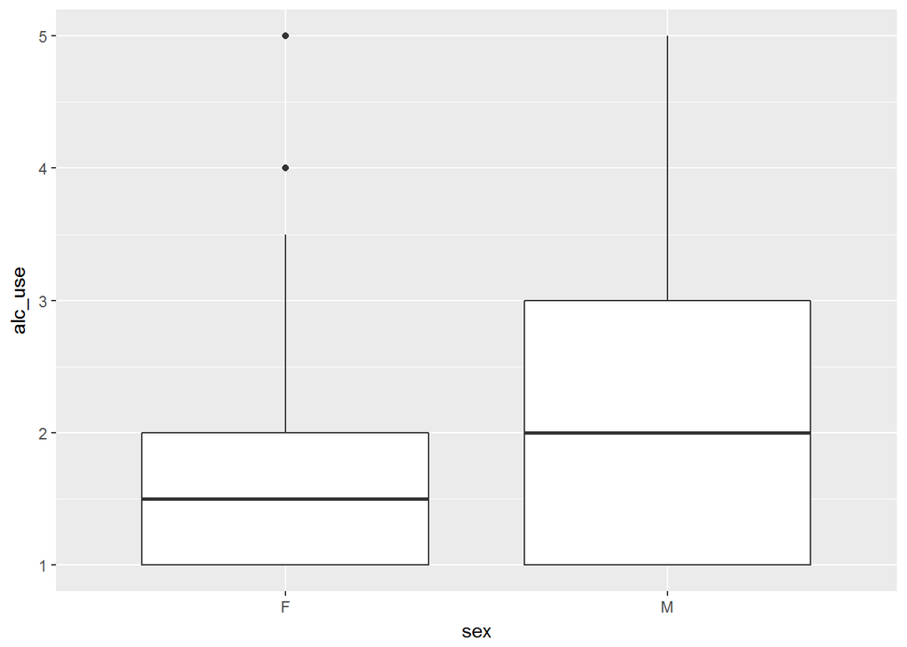

```r
g1 <- ggplot(data=alc, mapping=aes(x=sex, y=alc_use))
g2 <- g1 + geom_boxplot()
g2
```

```r
tab <- table(sex = alc$sex, high_use = alc$high_use)
tab
```

```
##    high_use
## sex FALSE TRUE
##   F   156   42
##   M   112   72
```

```r
tab2 <- prop.table(tab, 1) %>% addmargins()
tab2
```

```
##      high_use
## sex       FALSE      TRUE       Sum
##   F   0.7878788 0.2121212 1.0000000
##   M   0.6086957 0.3913043 1.0000000
##   Sum 1.3965744 0.6034256 2.0000000
```

Male students use more alcohol than female students. Approximately 40% of male students are high users of alcohol.

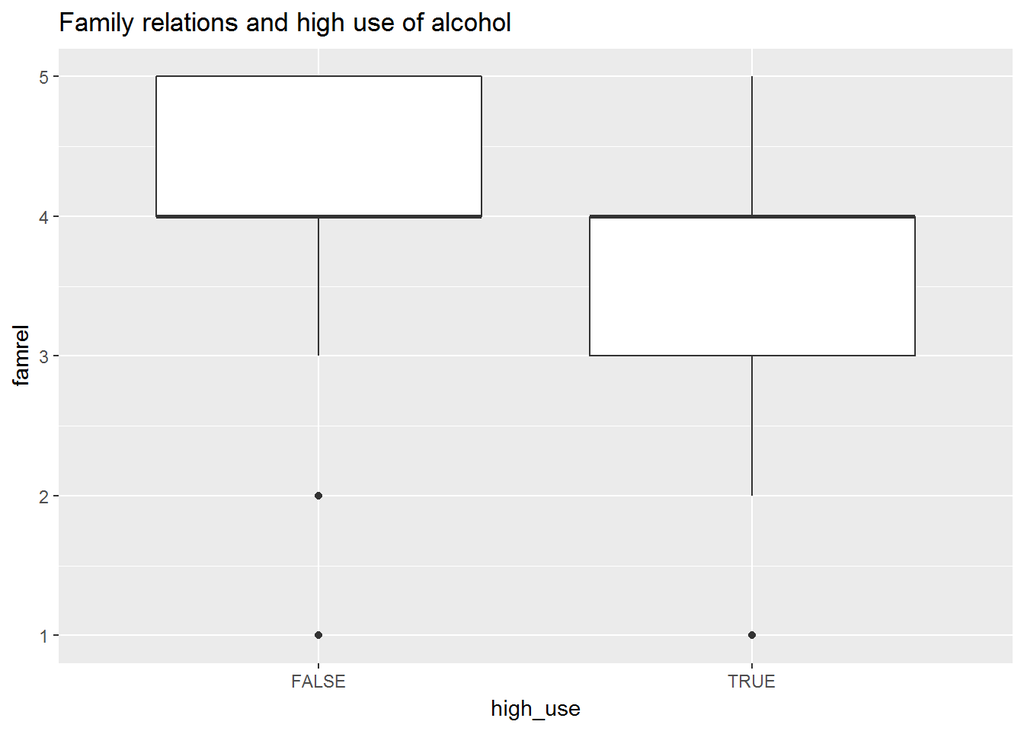

```r
family <- ggplot(data = alc, mapping = aes(x = high_use, y = famrel))
graph <- family + geom_boxplot() + ggtitle("Family relations and high use of alcohol")
graph
```

It seems that students who are high users of alcohol tend to have worse family relations than those who use less alcohol.

```r
HomeVsUse <- table(Pstatus = alc$Pstatus, high_use = alc$high_use)
HomeVsUse
```

```
##        high_use
## Pstatus FALSE TRUE
##       A    26   12
##       T   242  102
```

```r
prop.table(HomeVsUse, 1) %>% addmargins()
```

```
##        high_use
## Pstatus     FALSE      TRUE       Sum
##     A   0.6842105 0.3157895 1.0000000
##     T   0.7034884 0.2965116 1.0000000
##     Sum 1.3876989 0.6123011 2.0000000
```

Parents’ cohabitation status doesn’t seem to cause high alcohol use among students.

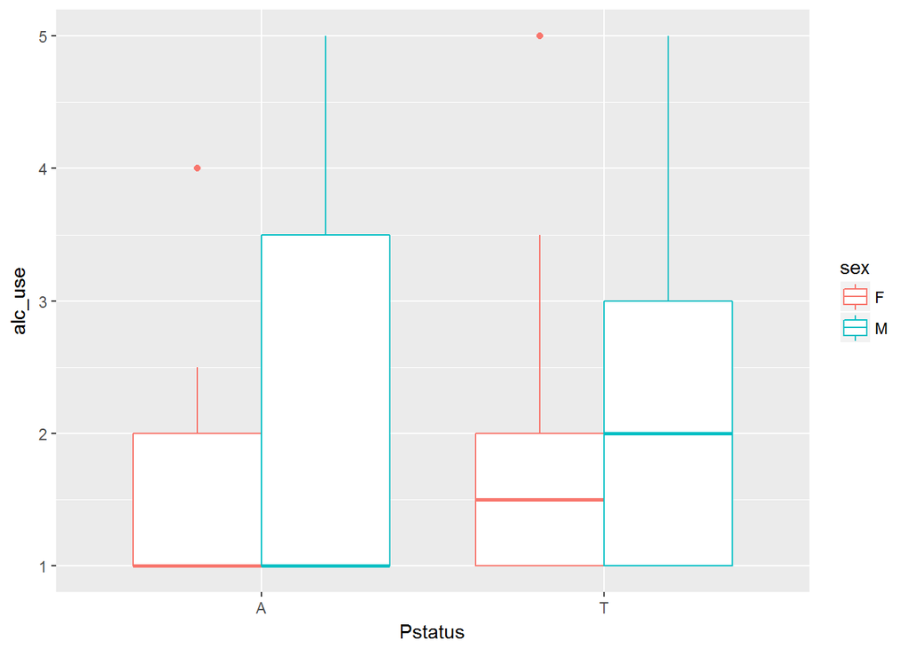

```r
home <- ggplot(data=alc, mapping = aes(x=Pstatus, y=alc_use, col=sex))
home2 <- home + geom_boxplot()
home2
```